# COVID-19 Spatial Analysis

Izzy Youngs

5/7/2020

## Analysis goals

1. Do higher density and public transit use correspond to more coronavirus cases?
2. What other variables might be correlated to COVID-19 cases?
3. What further research would confirm variables correlation or causation?
4. What urban planning policies might mitigate community transmission?

## Step-by-step documentation

### Merging variables in R

First I forked [The New York Times Coronavirus Github](https://github.com/nytimes/covid-19-data) and read in the case data. Then I took the case data and cleaned the county names so they would link across various datasets:

```
# #read in csv
case_data <- read_csv("~/GitHub/covid-19-data/us-counties.csv")

# #clean up names, first select everything to be changed
case_data_2 <- case_data %>%
  filter(county != "Carson City"
         & county != "St. Louis City"
         & county != "Fairfax City"
         & county != "Baltimore City"
         & county != "Kansas City"
         & county != "New York City"
         & county != "Franklin City"
         & county != "Richmond City"
         & county != "Roanoke City")

# #create a small data frame to add back when cleanup is done
case_data_3 <- case_data %>%
  filter(county %in% c("Carson City", "St. Louis City", "Fairfax City", "Franklin City", "Baltimore City", "New York City", "Richmond City", "Roanoke City"))

# #make a list of words to remove
wordstoremove <- c(" County", " City", " Parish", " and Borough", " Borough", " Municipality", " Census Area")%>%
  paste0(collapse = "|")

case_data_2 <- case_data_2 %>%
  mutate(county = str_remove_all(county, regex(str_c("\\b", wordstoremove, "\\b", collapse = "|"), ignore_case = T)),)

# #merge together
case_data <- rbind(case_data_2, case_data_3)

# #make fips field numeric
case_data$fips <- as.numeric(case_data$fips)
```

Capturing coronavirus cases at a single point in time would inaccurately reflect rates of community spread because some counties would have had it for several days or weeks before other counties. To standardize the ratios, I filtered the cases so that each county’s ratios were isolated 2 weeks from the first recorded case of coronavirus. Then I wrote the data to a spreadsheet to merge with the variables data.

```
# #filter
case_data <- case_data %>%
  filter(cases > 0) %>%
  group_by(date) %>%
  group_by(county, state) %>%
  slice(1L + 15)

county_data <- case_data[complete.cases(case_data$fips), ]

write_csv(county_data, "Data/case_data.csv")
```

```
# #read in csvs
county_pops <- read_csv("Data/county_population.csv")
pop_density <- read_csv("Data/usa_pop_density.csv")
aqi_data <- read_csv("Data/county_aqi_2019.csv")
stay_home <- read_csv("Data/stay_at_home.csv")
census_data <- read_csv("Data/census_tables.csv")
case_data <- read_csv("Data/final_data.csv") %>% select(c(-county, -state))

# #merge pop data
pop <- left_join(county_pops, pop_density, by = c("county", "state"))

# #merge population density to aqi data
pop_aqi <- left_join(pop, aqi_data, by = c("county", "state"))

# #merge pop_aqi data to stay at home orders
pop_aqi_orders <- left_join(pop_aqi, stay_home, by = "state")

# #merge pop_aqi_orders data to census data
pop_aqi_orders_census <- left_join(pop_aqi_orders, census_data, by = c("county", "state"))

# #merge pop_aqi_orders_census to case data
final_data <- left_join(pop_aqi_orders_census, case_data, by = "fips")
```

Then I calculated the case and death ratios by dividing the number of cases and deaths by the population and then multiplying by 100. Then I saved the data in a clean schema:

```
final_data$case_ratio <- final_data$cases / final_data$population * 100
final_data$deaths_ratio <- final_data$deaths / final_data$population * 100

final_data <- final_data %>% select(state, county, fips, population, pop_density, date, cases, case_ratio, deaths, deaths_ratio, everything())

write_csv(final_data, "Data/final_data.csv")
```

After this, I pulled in the final dataset to ArcGIS Pro and did an add join on the fips codes to a copied feature layer of the Esri [USA Counties (Generalized)](https://georgetownuniv.maps.arcgis.com/home/item.html?id=7566e0221e5646f99ea249a197116605) layer on Living Atlas.

Now the data has a geometry field and I can do analysis.

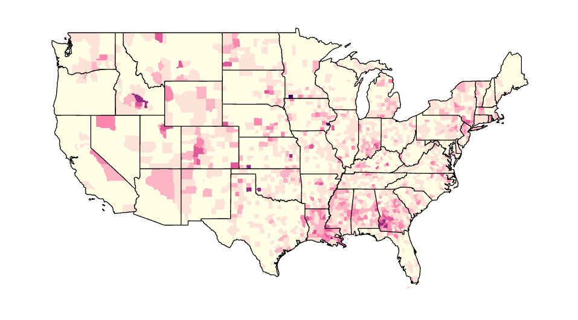

*Distribution of coronavirus cases*

### Hot Spot Analysis

First, I wanted to determine which areas are experiencing the worst effects of coronavirus, so I ran the Optimized Hot Spot Analysis geoprocessing tool in ArcGIS Pro on the case ratios.

The hot spot analysis geoprocessing tool creates a map of statistically significant hot and cold spots using the Getis-Ord Gi* statistic. This is better than visualizing the distribution and density of the phenomenon, because the statistic compares the underlying data against neighboring data to identify which counties are statistically hotter or colder.

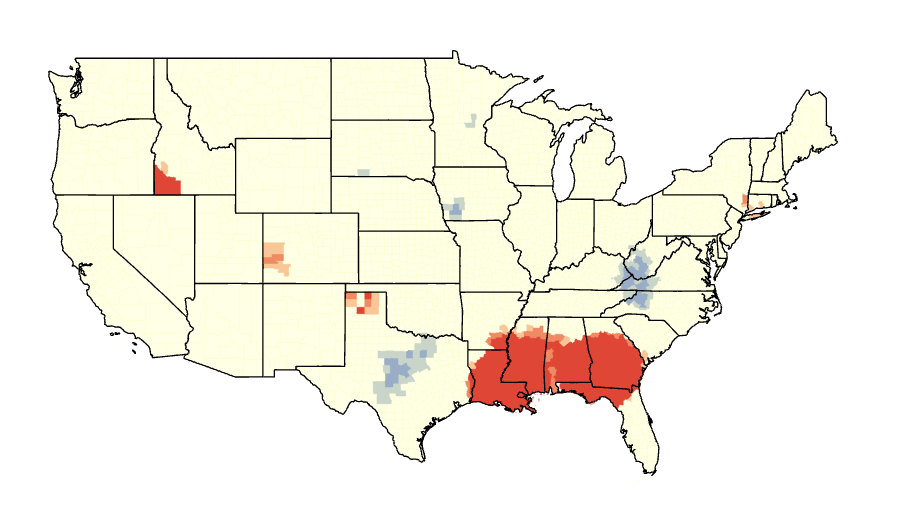

*Hot spot analysis of coronavirus cases*

### Outlier Analysis

To determine which counties might have a statistically significant difference in their case numbers, I ran an outlier analysis. This geoprocessing tool identifies statistically significant hot spots, cold spots, and spatial outliers using the Anselin Local Moran’s I statistic. This shows not only the hot and cold spots, but which counties within those hot and cold spots are outliers.

[figure not shown]

*Outlier analysis of coronavirus cases*

### Random Forest Regression

To illuminate which factors and variables drive the biggest differences in community spread of coronavirus, I turned to Random Forest Regression, a supervised learning technique which combines the results of multiple decision trees and then aggregates them, making it more powerful than any single decision tree, which tend to overfit the data. Random Forest Regressions attempt to predict the value of a single variable (in this example, the case ratio) based on the values of other variables selected.

#### Data requirements

Based on various reports about the potential transmission factors, I isolated the following variables for analysis:

| CRITERIA | DEFINED AS | SPATIAL FEATURES | ATTRIBUTE INFORMATION | DATASET | PREPARATION |
| --- | --- | --- | --- | --- | --- |
| Population density | People per square mile in a county | County attributes | Population per square mile, fips for county or county AND state name | Esri Living Atlas | Copy features, export table, clean attributes, link by geometry |
| Race by age | ACS demographic data | County attributes | Percentage of population is of specific race and age category, fips for county or county AND state name | Census tables, 5 year ACS 2018 from NHGIS | Make each count a percentage of the population, rename column headers for readability, link by geometry |
| Household type | ACS household makeup attributes | County attributes | Percentage of households per type, fips for county or county AND state name | Census tables, 5 year ACS 2018 from NHGIS | Make each count a percentage of the population, rename column headers for readability, link by geometry |
| Transportation modes | ACS transportation modes | County attributes | Percentage of population takes different transit types, fips for county or county AND state name | Census tables, 5 year ACS 2018 from NHGIS | Make each count a percentage of the population, rename column headers for readability, link by geometry |
| Occupation | ACS industry occupations | County attributes | Percentage of population in various industrise, fips for county or county AND state name | Census tables, 5 year ACS 2018 from NHGIS | Make each count a percentage of the population, rename column headers for readability, link by geometry |
| Air pollution | Air quality index | County attributes | Average amount of GHG per county, county fips or county AND state name | EPA air pollution numbers for 2019 | Link across all counties, replace NA values with a presumptive 0 so that the random forest regression works |
| Strictness of prevention policies | The relative strictness of various state policies | State attributes | Various prevention policies by state | Kaiser Family Foundation | Link across all states and eliminate attributes with too few variation for analysis |

Then I located the “Forest-based Classifcation and Regression (Spatial Statistics Tools)” geoprocessing tool, and ran a training model on the case ratios by county for all the variables I identified, and indicated I wanted a validation table:

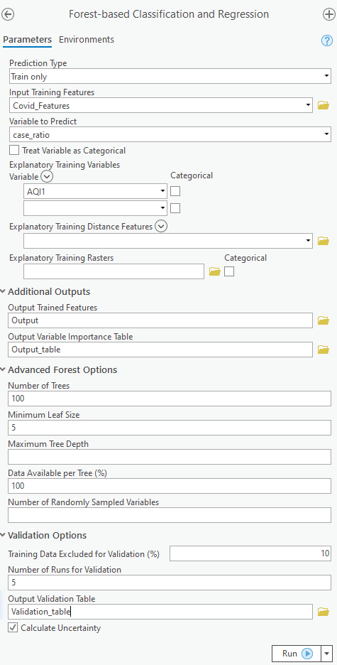

*Forest-based Classifcation and Regression geoprocessing tool*

From this analysis, I got the following results:

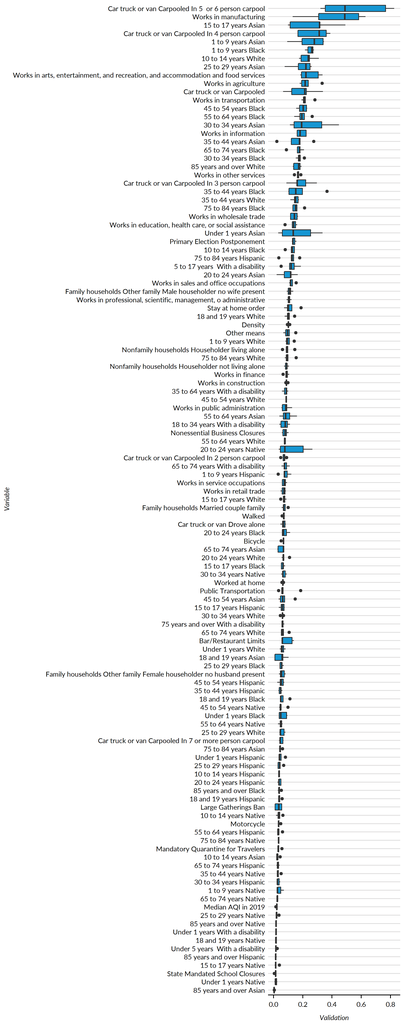

*Forest-based Classifcation and Regression results*

### Additional walk-throughs

Then I clicked “Calculate” and chose the new field name I just created in the appropriate input table. Then I added the variables and Arcade expressions needed to generate the new field for visualization or analysis:

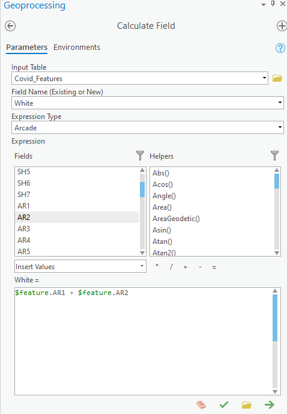

*Calculate field tool*

This tool allowed me to flexibly change which variables to symbolize and analyze without having to recreate the data tables in R. With this tool, I was able to:

- Compare coronavirus case ratios to population density
- Aggregate all variables in a category (transit type = car-related)
- Subset variables for analysis (age and race)

## Storymap

[Completed Storymap](https://storymaps.arcgis.com/stories/078d683198194fc5973907cfd303171f)